# IODS course project

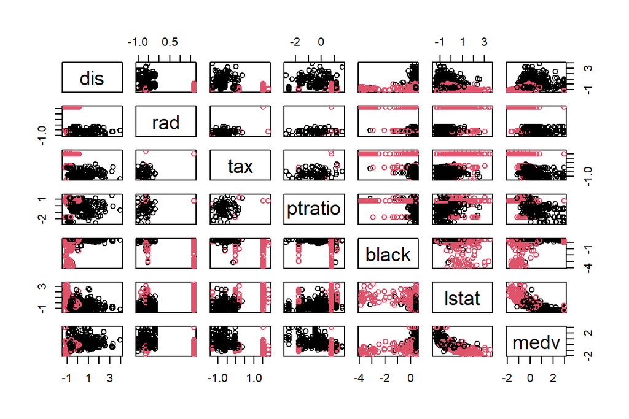

```r
pairs(boston_scaled2[8:14], col =km_f$cluster)
```

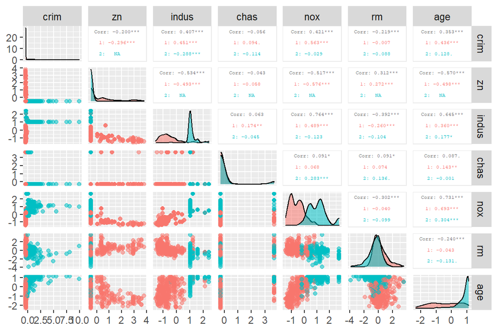

```r
#transforming km_f into a factor for the visualization
km_f$cluster <- as.factor(km_f$cluster)

#some further visualization with the two subsets
ggpairs(boston_scaled2[1:7],lower = list(combo = wrap("facethist", bins = 20)),upper = list(continuous = wrap("cor", size = 1.5)),  mapping=ggplot2::aes(colour = km_f$cluster, alpha=0.5))
```

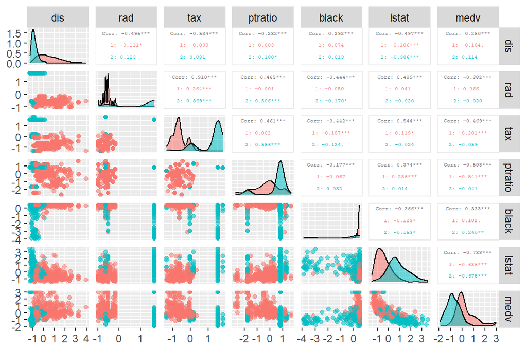

```r
ggpairs(boston_scaled2[8:14],lower = list(combo = wrap("facethist", bins = 20)),upper = list(continuous = wrap("cor", size = 1.5)),  mapping=ggplot2::aes(colour = km_f$cluster, alpha=0.5))
```

The plots indicate that most of the variables are differently distributed among the two clusters. Still, it is difficult to say which variables would differ significantly. At least crim (crime rate), indus (amount of non-retail business acres), nox (nitrogen oxides concentration), lstat (amount of lower status in the population), tax (property-tax), rad (accessibility to radial highways), dis (distance to employment centers), and age appear to separate between the clusters. Overall, the clusters seem to partially differentiate between higher and lower-class neighborhoods.  
Bonus:

1. Fitting an additional K-means cluster analysis with 3 clusters to the standardized data,  
   and 2. Performing an LDA using the clusters as target classes

```r
#Performing the cluster analysis
km3 <-kmeans(boston_scaled2, centers = "3")

#making the target variable numeric
clusters <- as.numeric(km3$cluster)
#adding the target variable into the data
boston_scaled2 <- data.frame(boston_scaled2, clusters)


#OBS! I had to comment out the below code because the lda-function gave an error when knitting "variable 4 appears to be constant within groups calls". I could not find a way to fix it. The text in the end is based on the results that I got (before knitting the document).

#Including all the variables in the Boston data as predictors in the LDA
#lda.fit2 <- lda(clusters ~ ., data = boston_scaled2)

#printing the LDA object
#lda.fit2

#Visualize the results with a biplot (include arrows representing the relationships of the original variables to the LDA solution).

# the function for lda biplot arrows
lda.arrows <- function(x, myscale = 1, arrow_heads = 0.1, color = "blue", tex = 0.75, choices = c(1,2)){
  heads <- coef(x)
  arrows(x0 = 0, y0 = 0,
         x1 = myscale * heads[,choices[1]],
         y1 = myscale * heads[,choices[2]], col=color, length = arrow_heads)
  text(myscale * heads[,choices], labels = row.names(heads),
       cex = tex, col=color, pos=3)
}

#creating the plot
#plot(lda.fit2, dimen = 2, col=clusters, pch=clusters)
#lda.arrows(lda.fit2, myscale = 4.5)
```

[output not shown]

# 5. Dimensionality reduction techniques (week5)

## 5.1 Loading in data

```r
#Loading in the data from my local data folder, row.names=1 keeps the country names as row names.
setwd("./data")
human_ <- read.csv("humanf.csv", row.names=1)

head(human_,4)
```

```
##             edu2_ftom labour_ftom Edu_exp life_exp   GNI mat_mor Adol_birth
## Norway      1.0072389   0.8908297    17.5     81.6 64992       4        7.8
## Australia   0.9968288   0.8189415    20.2     82.4 42261       6       12.1
## Switzerland 0.9834369   0.8251001    15.8     83.0 56431       6        1.9
## Denmark     0.9886128   0.8840361    18.7     80.2 44025       5        5.1
##             parl_f
## Norway        39.6
## Australia     30.5
## Switzerland   28.5
## Denmark       38.0
```

```r
dim(human_) # seems good
```

```
## [1] 155   8
```

```r
#loading libraries
library(GGally)
library(ggplot2)
library(corrplot)
library(tidyverse)
```

## 5.2 A graphical overview of the data and summaries of the variables

```r
#variable summaries
summary(human_)
```

```
##    edu2_ftom       labour_ftom        Edu_exp         life_exp
##  Min.   :0.1717   Min.   :0.1857   Min.   : 5.40   Min.   :49.00
##  1st Qu.:0.7264   1st Qu.:0.5984   1st Qu.:11.25   1st Qu.:66.30
##  Median :0.9375   Median :0.7535   Median :13.50   Median :74.20
##  Mean   :0.8529   Mean   :0.7074   Mean   :13.18   Mean   :71.65
##  3rd Qu.:0.9968   3rd Qu.:0.8535   3rd Qu.:15.20   3rd Qu.:77.25
##  Max.   :1.4967   Max.   :1.0380   Max.   :20.20   Max.   :83.50
##       GNI            mat_mor         Adol_birth         parl_f
##  Min.   :   581   Min.   :   1.0   Min.   :  0.60   Min.   : 0.00
##  1st Qu.:  4198   1st Qu.:  11.5   1st Qu.: 12.65   1st Qu.:12.40
##  Median : 12040   Median :  49.0   Median : 33.60   Median :19.30
##  Mean   : 17628   Mean   : 149.1   Mean   : 47.16   Mean   :20.91
##  3rd Qu.: 24512   3rd Qu.: 190.0   3rd Qu.: 71.95   3rd Qu.:27.95
##  Max.   :123124   Max.   :1100.0   Max.   :204.80   Max.   :57.50
```

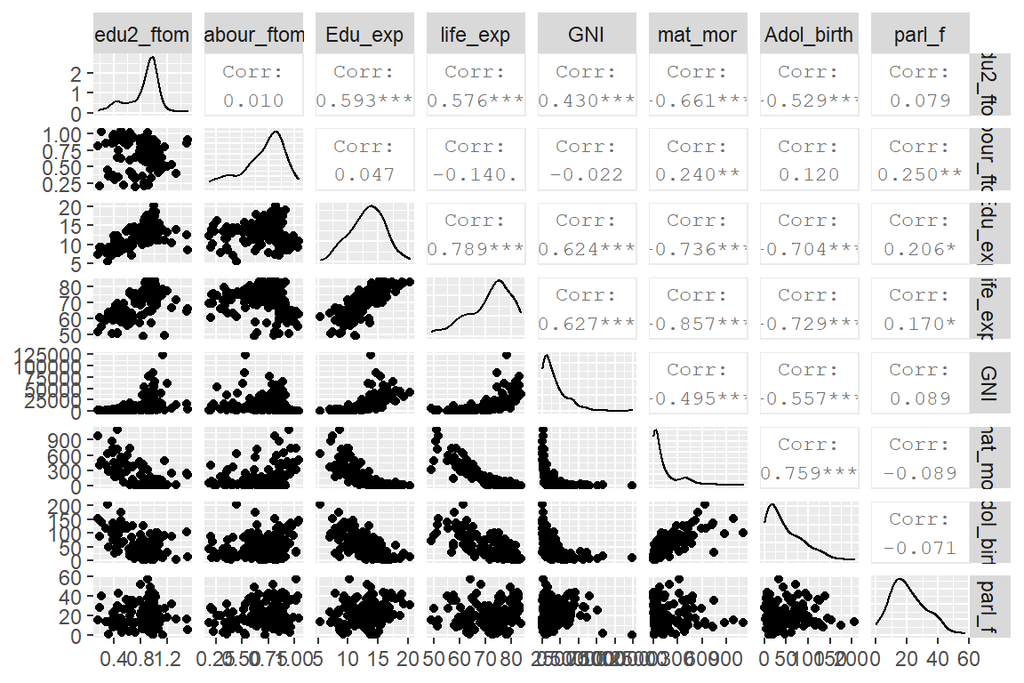

```r
#a graphical overview of the data
ggpairs(human_,lower = list(combo = wrap("facethist", bins = 20)), upper = list(continuous = wrap("cor", size = 3)))
```

```r
#looking more into the correlations
# calculating the correlation matrix and rounding it
cor_matrix<-cor(human_) %>% round(2)
#looking into the correlations
cor_matrix
```

```
##             edu2_ftom labour_ftom Edu_exp life_exp   GNI mat_mor Adol_birth
## edu2_ftom        1.00        0.01    0.59     0.58  0.43   -0.66      -0.53
## labour_ftom      0.01        1.00    0.05    -0.14 -0.02    0.24       0.12
## Edu_exp          0.59        0.05    1.00     0.79  0.62   -0.74      -0.70
## life_exp         0.58       -0.14    0.79     1.00  0.63   -0.86      -0.73
## GNI              0.43       -0.02    0.62     0.63  1.00   -0.50      -0.56
## mat_mor         -0.66        0.24   -0.74    -0.86 -0.50    1.00       0.76
## Adol_birth      -0.53        0.12   -0.70    -0.73 -0.56    0.76       1.00
## parl_f           0.08        0.25    0.21     0.17  0.09   -0.09      -0.07
##             parl_f
## edu2_ftom     0.08
## labour_ftom   0.25
## Edu_exp       0.21
## life_exp      0.17
## GNI           0.09
## mat_mor      -0.09
## Adol_birth   -0.07
## parl_f        1.00
```

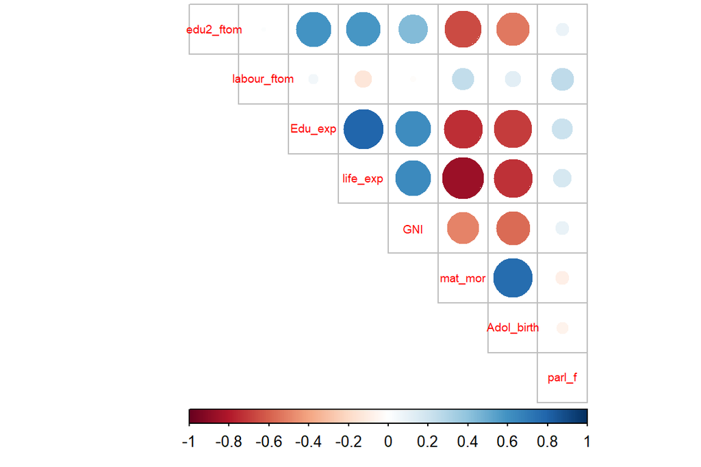

```r
# visualizing the correlation matrix
corrplot(cor_matrix, method="circle", type="upper", cl.pos="b", tl.pos="d",tl.cex=0.6)
```

**Descriptions of the variables:**

- edu2_ftom = Proportion of females / proportion of males with at least secondary education
- labour_ftom = Proportion of females / proportion of males in the labour force
- Edu_exp = Expected years of schooling
- life_exp = Life expectancy at birth
- GNI = Gross National Income per capita
- mat_mor = Maternal mortality ratio
- Adol_birth = Adolescent birth rate
- parl_f = Percentange of female representatives in parliament

**Some observations about the data:**

- In most countries, maternal mortality, GNI, and adolescent birth rate are relatively low.
- Proportion of females to males with a secondary education is quite normally distributed among the countries, although men do tend to have higher education than women.
- Expected years of schooling overall is more normally distributed
- Some of the strongest correlations are between 1) maternal mortality and life expectancy (r= -0.86), 2) life expectancy and expected years of schooling (r = 0.79), and 3) adolescent birth rate and maternal mortality (r= 0.76)

## 5.3 Perform principal component analysis (PCA) and draw a biplot displaying the observations by the first two principal components

```r
#PCA (with the SVD method)
pca_human <- prcomp(human_)
#printing the summary object and a summary of it
pca_human
```

```
## Standard deviations (1, .., p=8):
## [1] 1.854416e+04 1.855219e+02 2.518701e+01 1.145441e+01 3.766241e+00
## [6] 1.565912e+00 1.912052e-01 1.591112e-01
##
## Rotation (n x k) = (8 x 8):
##                       PC1           PC2           PC3           PC4
## edu2_ftom   -5.607472e-06  0.0006713951 -3.412027e-05 -2.736326e-04
## labour_ftom  2.331945e-07 -0.0002819357  5.302884e-04 -4.692578e-03
## Edu_exp     -9.562910e-05  0.0075529759  1.427664e-02 -3.313505e-02
## life_exp    -2.815823e-04  0.0283150248  1.294971e-02 -6.752684e-02
## GNI         -9.999832e-01 -0.0057723054 -5.156742e-04  4.932889e-05
## mat_mor      5.655734e-03 -0.9916320120  1.260302e-01 -6.100534e-03
## Adol_birth   1.233961e-03 -0.1255502723 -9.918113e-01  5.301595e-03
## parl_f      -5.526460e-05  0.0032317269 -7.398331e-03 -9.971232e-01
##                       PC5           PC6           PC7           PC8
## edu2_ftom   -0.0022935252  2.180183e-02  6.998623e-01  7.139410e-01
## labour_ftom  0.0022190154  3.264423e-02  7.132267e-01 -7.001533e-01
## Edu_exp      0.1431180282  9.882477e-01 -3.826887e-02  7.776451e-03
## life_exp     0.9865644425 -1.453515e-01  5.380452e-03  2.281723e-03
## GNI         -0.0001135863 -2.711698e-05 -8.075191e-07 -1.176762e-06
## mat_mor      0.0266373214  1.695203e-03  1.355518e-04  8.371934e-04
## Adol_birth   0.0188618600  1.273198e-02 -8.641234e-05 -1.707885e-04
## parl_f      -0.0716401914 -2.309896e-02 -2.642548e-03  2.680113e-03
```

```r
summary(pca_human) #this shows clearly the proportion of variance captured by each component. The first PC explains 99.9 % of the variance that is captured. It also shows the standard deviations.
```

```
## Importance of components:
##                              PC1      PC2   PC3   PC4   PC5   PC6    PC7    PC8
## Standard deviation     1.854e+04 185.5219 25.19 11.45 3.766 1.566 0.1912 0.1591
## Proportion of Variance 9.999e-01   0.0001  0.00  0.00 0.000 0.000 0.0000 0.0000
## Cumulative Proportion  9.999e-01   1.0000  1.00  1.00 1.000 1.000 1.0000 1.0000
```

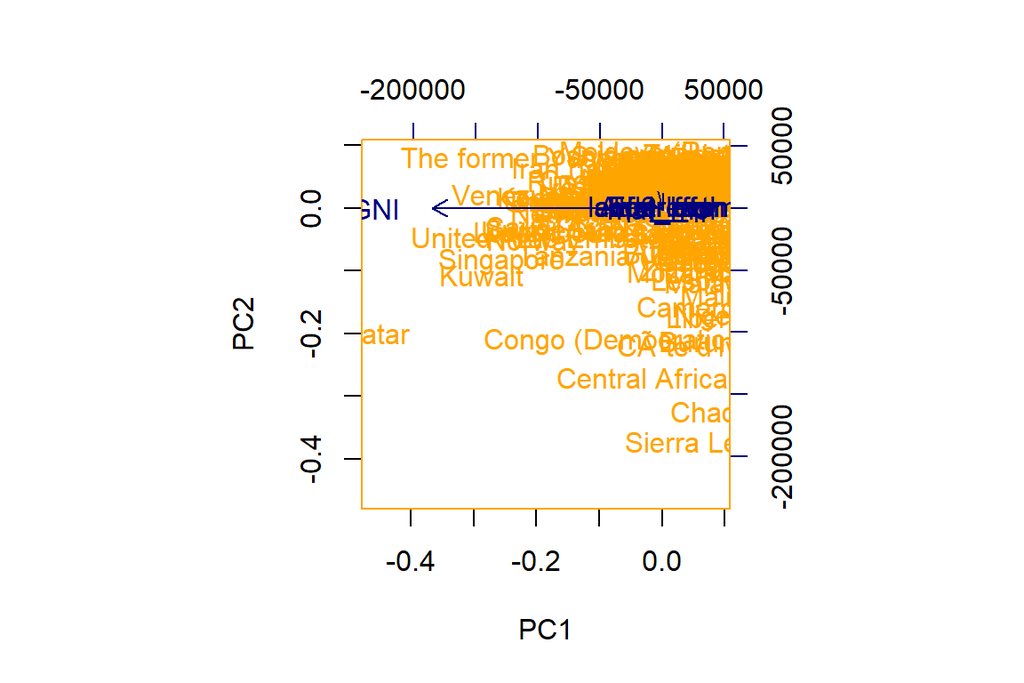

```r
#Drawing a biplot
biplot(pca_human, choices = 1:2, cex= c(1,1), col=c("orange", "navy"))
```

**Interpreting and commenting on the results:**

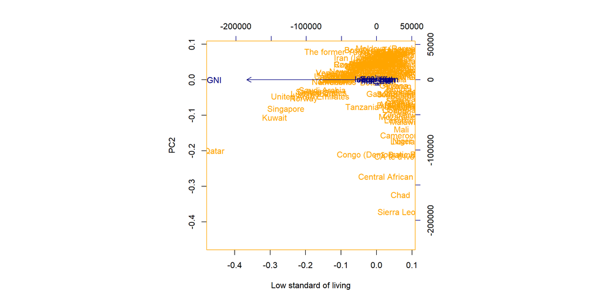

```r
#Let's draw the plot again but name the PC1 as "Low standard of living", see: http://hdr.undp.org/sites/default/files/hdr2015_technical_notes.pdf

biplot(pca_human, choices = 1:2, cex= c(1,1), col=c("orange", "navy"), xlab = "Low standard of living")
```

## 5.4 Standardizing the variables and running the PCA again

```r
#standardizing the data
human_std <- scale(human_)

summary(human_std) #seems good.
```

```
##    edu2_ftom        labour_ftom         Edu_exp           life_exp
##  Min.   :-2.8189   Min.   :-2.6247   Min.   :-2.7378   Min.   :-2.7188
##  1st Qu.:-0.5233   1st Qu.:-0.5484   1st Qu.:-0.6782   1st Qu.:-0.6425
##  Median : 0.3503   Median : 0.2316   Median : 0.1140   Median : 0.3056
##  Mean   : 0.0000   Mean   : 0.0000   Mean   : 0.0000   Mean   : 0.0000
##  3rd Qu.: 0.5958   3rd Qu.: 0.7350   3rd Qu.: 0.7126   3rd Qu.: 0.6717
##  Max.   : 2.6646   Max.   : 1.6632   Max.   : 2.4730   Max.   : 1.4218
##       GNI             mat_mor          Adol_birth          parl_f
##  Min.   :-0.9193   Min.   :-0.6992   Min.   :-1.1325   Min.   :-1.8203
##  1st Qu.:-0.7243   1st Qu.:-0.6496   1st Qu.:-0.8394   1st Qu.:-0.7409
##  Median :-0.3013   Median :-0.4726   Median :-0.3298   Median :-0.1403
##  Mean   : 0.0000   Mean   : 0.0000   Mean   : 0.0000   Mean   : 0.0000
##  3rd Qu.: 0.3712   3rd Qu.: 0.1932   3rd Qu.: 0.6030   3rd Qu.: 0.6127
##  Max.   : 5.6890   Max.   : 4.4899   Max.   : 3.8344   Max.   : 3.1850
```

```r
#PCA (with the SVD method)
pca_humanstd <- prcomp(human_std)

pca_humanstd
```

```
## Standard deviations (1, .., p=8):
## [1] 2.0708380 1.1397204 0.8750485 0.7788630 0.6619563 0.5363061 0.4589994
## [8] 0.3222406
##
## Rotation (n x k) = (8 x 8):
##                     PC1         PC2         PC3         PC4        PC5
## edu2_ftom   -0.35664370  0.03796058 -0.24223089  0.62678110 -0.5983585
## labour_ftom  0.05457785  0.72432726 -0.58428770  0.06199424  0.2625067
## Edu_exp     -0.42766720  0.13940571 -0.07340270 -0.07020294  0.1659678
## life_exp    -0.44372240 -0.02530473  0.10991305 -0.05834819  0.1628935
## GNI         -0.35048295  0.05060876 -0.20168779 -0.72727675 -0.4950306
## mat_mor      0.43697098  0.14508727 -0.12522539 -0.25170614 -0.1800657
## Adol_birth   0.41126010  0.07708468  0.01968243  0.04986763 -0.4672068
## parl_f      -0.08438558  0.65136866  0.72506309  0.01396293 -0.1523699
##                     PC6         PC7         PC8
## edu2_ftom    0.17713316  0.05773644  0.16459453
## labour_ftom -0.03500707 -0.22729927 -0.07304568
## Edu_exp     -0.38606919  0.77962966 -0.05415984
## life_exp    -0.42242796 -0.43406432  0.62737008
## GNI          0.11120305 -0.13711838 -0.16961173
## mat_mor      0.17370039  0.35380306  0.72193946
## Adol_birth  -0.76056557 -0.06897064 -0.14335186
## parl_f       0.13749772  0.00568387 -0.02306476
```

```r
summary(pca_humanstd) # a more reasonable/useful finding with the  first PC explaining 54% of the variance, 2nd PC explaining 16% and third explaining 10% etc.
```

```
## Importance of components:
##                           PC1    PC2     PC3     PC4     PC5     PC6     PC7
## Standard deviation     2.0708 1.1397 0.87505 0.77886 0.66196 0.53631 0.45900
## Proportion of Variance 0.5361 0.1624 0.09571 0.07583 0.05477 0.03595 0.02634
## Cumulative Proportion  0.5361 0.6984 0.79413 0.86996 0.92473 0.96069 0.98702
##                            PC8
## Standard deviation     0.32224
## Proportion of Variance 0.01298
## Cumulative Proportion  1.00000
```

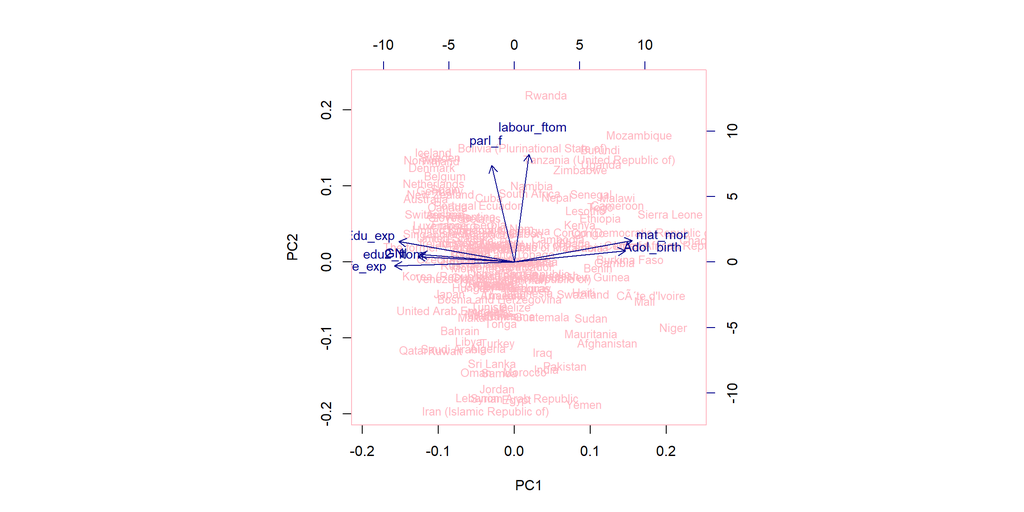

```r
#Drawing the biplot
biplot(pca_humanstd, choices = 1:2, cex= c(0.8,0.9), col=c("lightpink", "darkblue"))
```

**Interpreting and commenting on the results:**

- With the standardized variables the PCA results seem a lot more informative (and reliable!). This is because in PCA variables with high standard deviations (and variance overall) tend to get more weight than their importance would actually justify. Thus, standardization of variables is useful and often important before running a PCA.
- The results show that the first PC covers 54% of the variance and the second PC covers 16% of the variance.
- The biplot and the results show that the first dimension represents matters such as: life_exp (neg), edu_exp (neg), GNI (neg), Adol_birth (posit), mat_mor (posit), edu2_ftom (neg). Thus it could be named “Low standard of living and education”.
- The second dimension (PC2) mainly captures variables measuring: labour_ftom (posit), parl_f (posit) and could thus be termed “Equality”.
- The biplot shows that certain countries can quite clearly be set apart from the rest of the countries based on these two components. Similar countries also cluster together, for instance some European countries (Belgium, Netherlands) are located in the upper left corner/quarter of the plot with quite high equality.

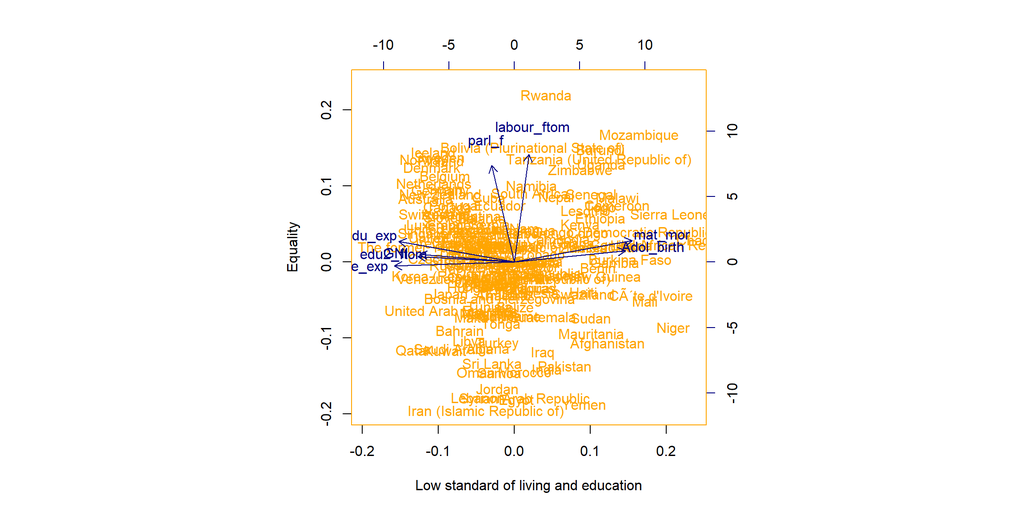

```r
#Let's draw the plot again so that PC1 is named "Standard of living and education" and PC2 is named "Equality".

biplot(pca_humanstd, choices = 1:2, cex= c(1,1), col=c("orange", "navy"), xlab = "Low standard of living and education", ylab= "Equality")
```

## 5.5 Loading and exploring a new dataset

```r
#Load the tea dataset from the package Factominer.
library(FactoMineR)
data("tea")

dim(tea) #300 obs, 36 var.
```

```
## [1] 300  36
```

```r
head(tea,6) #data largely strings, text format variables
```

```
##       breakfast     tea.time     evening     lunch     dinner     always home
## 1     breakfast Not.tea time Not.evening Not.lunch Not.dinner Not.always home
## 2     breakfast Not.tea time Not.evening Not.lunch Not.dinner Not.always home
## 3 Not.breakfast     tea time     evening Not.lunch     dinner Not.always home
## 4 Not.breakfast Not.tea time Not.evening Not.lunch     dinner Not.always home
## 5     breakfast Not.tea time     evening Not.lunch Not.dinner     always home
## 6 Not.breakfast Not.tea time Not.evening Not.lunch     dinner Not.always home
##       work     tearoom     friends     resto     pub       Tea   How    sugar
## 1 Not.work Not.tearoom Not.friends Not.resto Not.pub     black alone    sugar
## 2 Not.work Not.tearoom Not.friends Not.resto Not.pub     black  milk No.sugar
## 3     work Not.tearoom     friends     resto Not.pub Earl Grey alone No.sugar
## 4 Not.work Not.tearoom Not.friends Not.resto Not.pub Earl Grey alone    sugar
## 5 Not.work Not.tearoom Not.friends Not.resto Not.pub Earl Grey alone No.sugar
## 6 Not.work Not.tearoom Not.friends Not.resto Not.pub Earl Grey alone No.sugar
##       how       where           price age sex          SPC         Sport age_Q
```

[output cut: 27 more lines]

```r
str(tea) # variables are of type factor and most of them have two levels. The data measures matters related to tea consumption.
```

```
## 'data.frame':    300 obs. of  36 variables:
##  $ breakfast       : Factor w/ 2 levels "breakfast","Not.breakfast": 1 1 2 2 1 2 1 2 1 1 ...
##  $ tea.time        : Factor w/ 2 levels "Not.tea time",..: 1 1 2 1 1 1 2 2 2 1 ...
##  $ evening         : Factor w/ 2 levels "evening","Not.evening": 2 2 1 2 1 2 2 1 2 1 ...
##  $ lunch           : Factor w/ 2 levels "lunch","Not.lunch": 2 2 2 2 2 2 2 2 2 2 ...
##  $ dinner          : Factor w/ 2 levels "dinner","Not.dinner": 2 2 1 1 2 1 2 2 2 2 ...
##  $ always          : Factor w/ 2 levels "always","Not.always": 2 2 2 2 1 2 2 2 2 2 ...
##  $ home            : Factor w/ 2 levels "home","Not.home": 1 1 1 1 1 1 1 1 1 1 ...
##  $ work            : Factor w/ 2 levels "Not.work","work": 1 1 2 1 1 1 1 1 1 1 ...
##  $ tearoom         : Factor w/ 2 levels "Not.tearoom",..: 1 1 1 1 1 1 1 1 1 2 ...
##  $ friends         : Factor w/ 2 levels "friends","Not.friends": 2 2 1 2 2 2 1 2 2 2 ...
##  $ resto           : Factor w/ 2 levels "Not.resto","resto": 1 1 2 1 1 1 1 1 1 1 ...
##  $ pub             : Factor w/ 2 levels "Not.pub","pub": 1 1 1 1 1 1 1 1 1 1 ...
##  $ Tea             : Factor w/ 3 levels "black","Earl Grey",..: 1 1 2 2 2 2 2 1 2 1 ...
##  $ How             : Factor w/ 4 levels "alone","lemon",..: 1 3 1 1 1 1 1 3 3 1 ...
```

[output cut: 22 more lines]

```r
#visualizing the data with bar plots
#first, selecting parts of the data
tea1 <- dplyr::select(tea, 1:13)
tea2 <- dplyr::select(tea, 14:25)
tea3 <- dplyr::select(tea, 26:36)
```

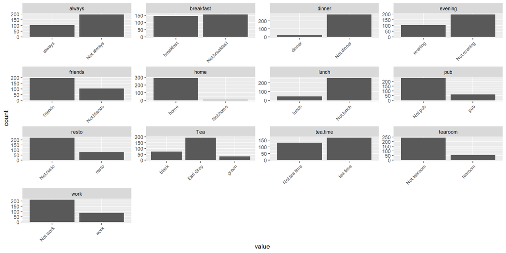

```r
#drawing the plots
gather(tea1) %>% ggplot(aes(value)) + facet_wrap("key", scales = "free") + geom_bar () + theme(axis.text.x = element_text(angle = 45, hjust = 1, size = 8))
```

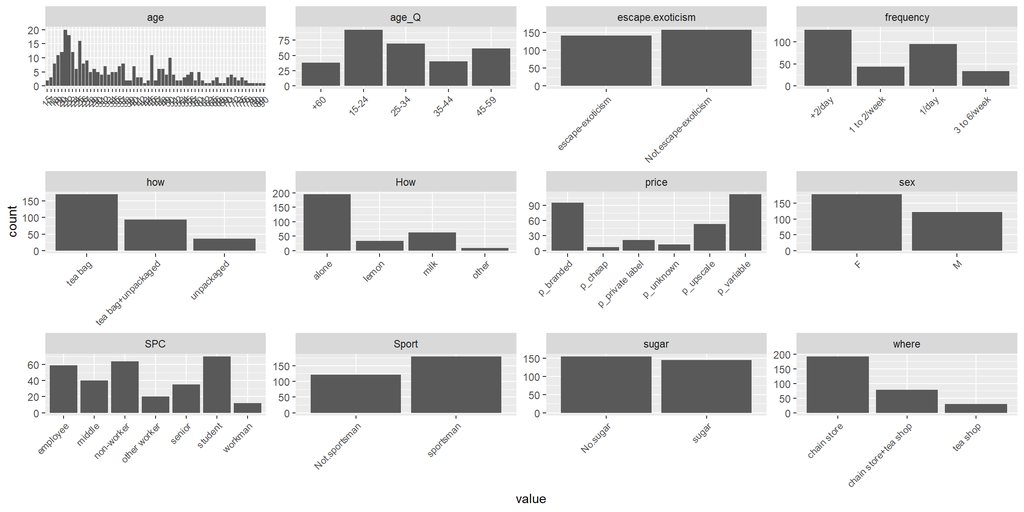

```r
gather(tea2) %>% ggplot(aes(value)) + facet_wrap("key", scales = "free") + geom_bar () + theme(axis.text.x = element_text(angle = 45, hjust = 1, size = 8))
```

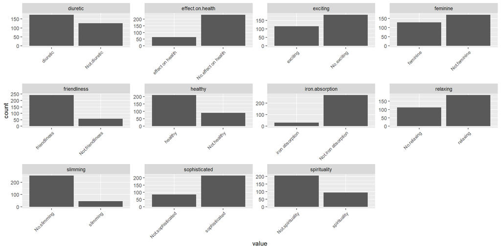

```r
gather(tea3) %>% ggplot(aes(value)) + facet_wrap("key", scales = "free") + geom_bar () + theme(axis.text.x = element_text(angle = 45, hjust = 1, size = 8))
```